# Performance Study of TCP Congestion Control

### Cheuk Ng (cn9475)

### Introduction

This is a study to compare the performance of different TCP congestion control algorithms, four congestion control algorithms are selected: **Reno**, **Cubic**, **Highspeed** and **Vegas**.

All the tests are performed in a virtual network provided by Mininet, each algorithm is tested with 3 different propagation delays (21ms, 81ms & 162ms), and is performed 3 times for each delay in the same network configuration, and the data is collected by using iPerf(v2.0.5) & Tcpprope. Due to the limitation of hardware and software, the data collected from these tests may be precise as experiments carried out in a physical network, but these algorithm should behave the same for a high-level comparison.

### Congestion Control Algorithm: Reno

TCP Reno is one of the early version of congestion control algorithm, it works very similar to TCP Tahoe: Transmission starts at a very low send rate and grows exponentially, then grows linearly after reaches to the slow-start threshold. The differences with Tahoe is that, Reno incorporates fast recovery. Whenever a loss event occurs, it updates the slow-start threshold using the cwnd instead of dropping it to 1 MMS like Tahoe, this can avoid going back to slow start and interrupt the flow, and hence more performant than Tahoe. Reno works very well for recovering from one packet loss, for multiple packet loss, the cwnd could drop to its minimum value.

#### Reno with 21ms delay

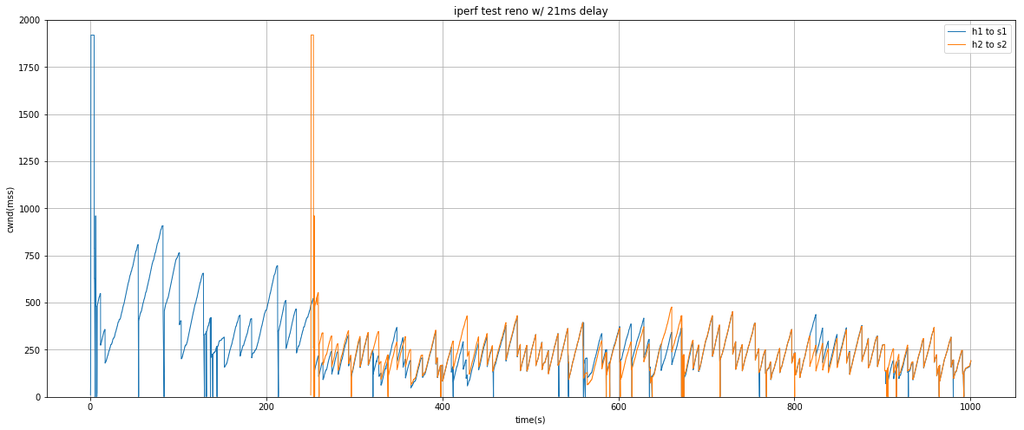

```python
run -i ./src/plot_tcpprobe.py reno 21
```

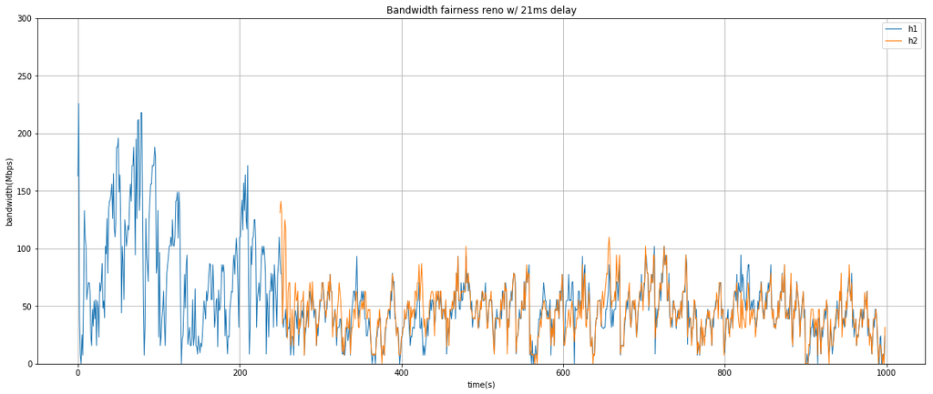

```python
run -i ./src/plot_fairness.py reno 21
```

#### Reno with 81ms delay

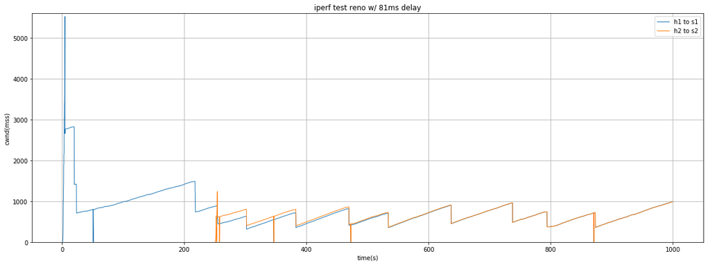

```python
run -i ./src/plot_tcpprobe.py reno 81
```

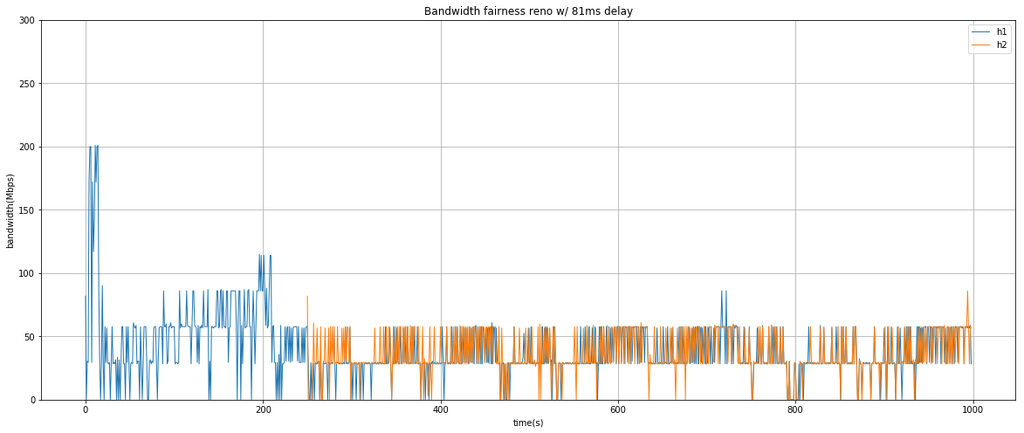

```python
run -i ./src/plot_fairness.py reno 81
```

#### Reno with 162ms delay

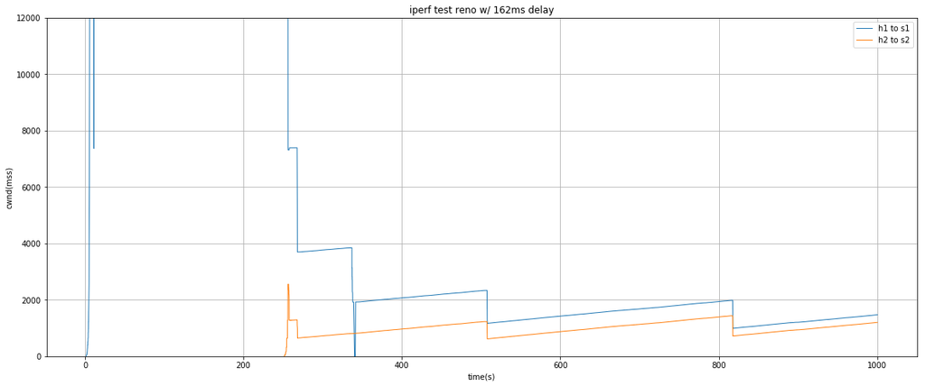

```python
run -i ./src/plot_tcpprobe.py reno 162
```

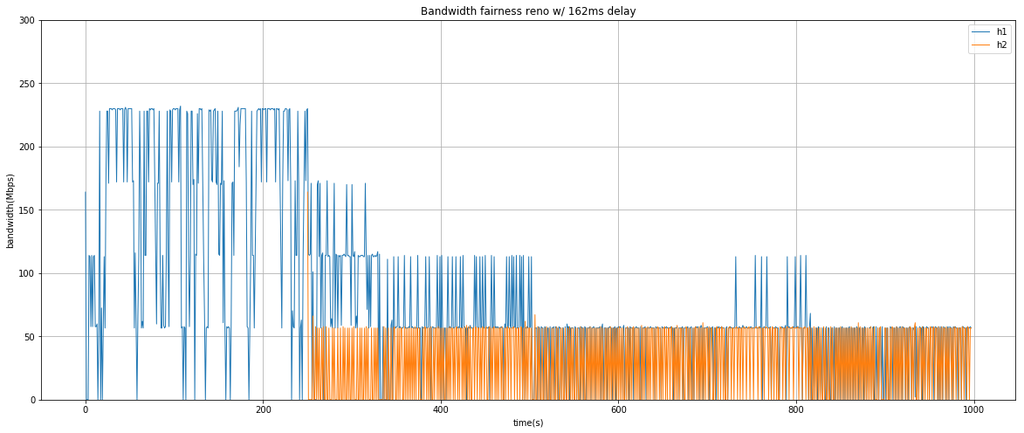

```python
run -i ./src/plot_fairness.py reno 162
```

### Observations

##### Cwnd changes

All three graphs shows a linear grow for the cwnd size in the congestion avoidance phase, and it is able to identify slow start, congestion avoidance & fast recovery phases from the graphs.

##### TCP Fairness

Before the transmission of h2, h1 occupies most of the bandwidth, then it eventually drops to the same amount of bandwidth usage as h2, the rate of bandwidth usage dropping getting slower for a longer RTT which takes longer for both hosts to adjust for a fairness sharing.

##### Performance

Since the grow is triggered by ACK arrival, a link with long delay affects the performance and the slow grow in cwnd makes it taking longer to reach high bandwidth usage, in result, it might take longer to finished the slow start phase and reach high bandwidth, also when competing with flows with a shorter RTT, this may cause unfair sharing of link capacity due to the slow grow of cwnd.

Average bandwidth utilization for 2 hosts is approximately 150Mbps, which is 59% of the total bandwidth.

### Congestion Control Algorithm: Cubic

Cubic is the default congestion control algorithm in Linux, it amis to provide a better solution compare to Reno in all situation. It grows the window by using a cubic function instead of a linear one used in Reno. When it recovers from a packet loss, it grows fast before reaching the previous cwnd, then slows down around it and increase the growth rate again after passing it. Thus, it forms a concave and convex growth in the congestion avoidance phase to stabilize the network before getting more bandwidth. Besides, the growth function is not depending on RTT, so the disadvantage of less performant in a link with long RTT does not apply to Cubic.

#### Cubic with 21ms delay

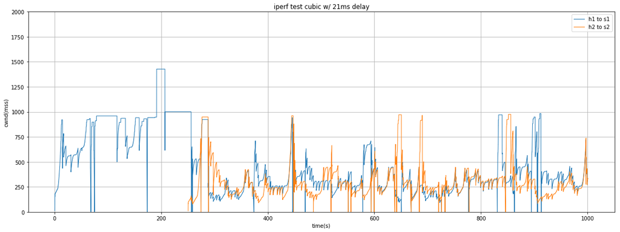

```python
run -i ./src/plot_tcpprobe.py cubic 21
```

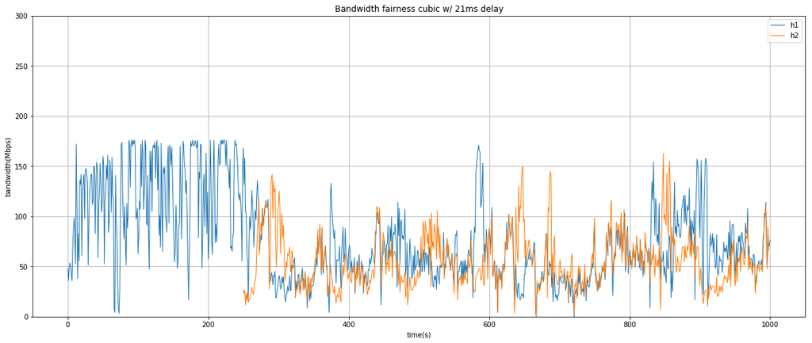

```python
run -i ./src/plot_fairness.py cubic 21
```

#### Cubic with 81ms delay

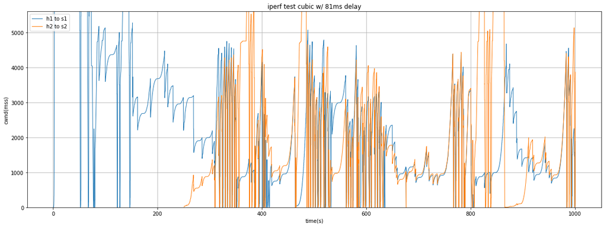

```python
run -i ./src/plot_tcpprobe.py cubic 81
```

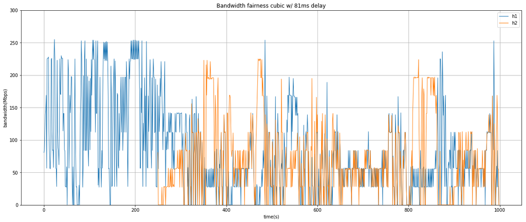

```python
run -i ./src/plot_fairness.py cubic 81
```

#### Cubic with 162ms delay

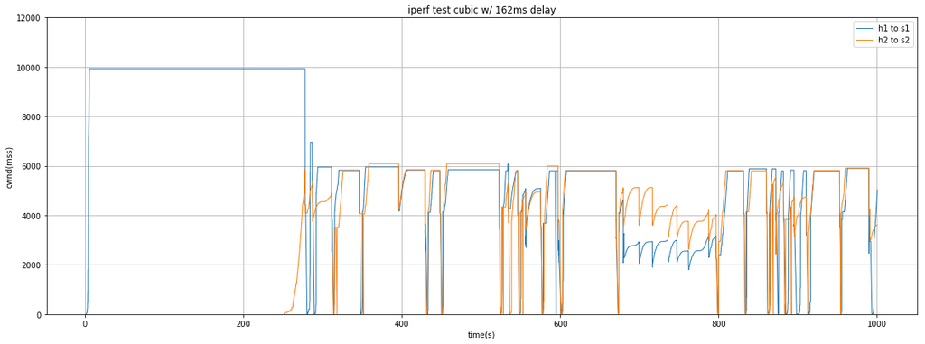

```python
run -i ./src/plot_tcpprobe.py cubic 162
```

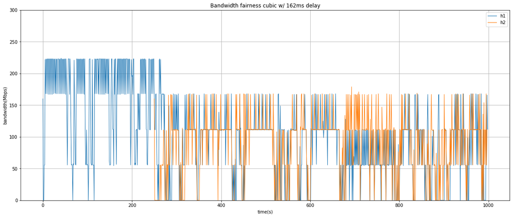

```python
run -i ./src/plot_fairness.py cubic 162
```

### Observations

##### Cwnd changes

Among all other congestion control algorithms, Cubic produces the graph with most noise: cwnd drops to close to 0 and then immediately bounces up to the max cwnd. This could be explained by TCP timeout, the cwnd and bandwidth usage drop to a minimum value when a TCP timeout occurs, then slow start kicks off in the next time interval and case the spike in the graph. Despite the noise in the graph, the overall cwnd behavior match with the expectation: slow start follows by congestion avoidance which is using a cubic function and show a concave & convex curve in the graph.

##### TCP Fairness

The noise affects the stability of the bandwidth graph. If we also look at the cwnd vs time graph, we can see a more obvious drop for h1 when h2 joins the transmission, and then they stay in the same region with minor up and down adjustments before they become synchronized and longer RTT tends to take a longer period of time for bandwidth usage synchronization.

##### Performance

Average bandwidth utilization for Cubic with 2 hosts is approximately 200Mbps, which is 79% of the total bandwidth and it is the highest among the 4 algorithms.

### Congestion Control Algorithm: Highspeed

The performance of congestion control algorithm that depend on ACK is not very optimized for connection with large Bandwidth-Delay Product, because the bandwidth cannot be fully utilized due to slow cwnd growth. Highspeed TCP aims to provide a solution to overcome this limitation. Similar to Reno, Highspeed TCP has the slow start and congestion avoidance phases and a similar rate of change for cwnd as Reno for a small BDP connection, however, a connection with a BDP larger than a threshold, the cwnd function return a greater value for growth and smaller value for decreasing cwnd, so as to get more bandwidth in a shorter period of time.

#### Highspeed with 21ms delay

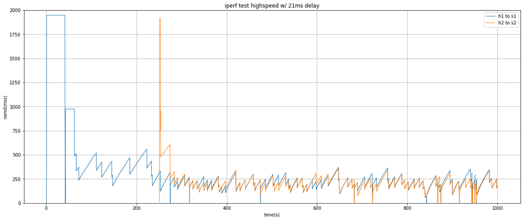

```python
run -i ./src/plot_tcpprobe.py highspeed 21
```

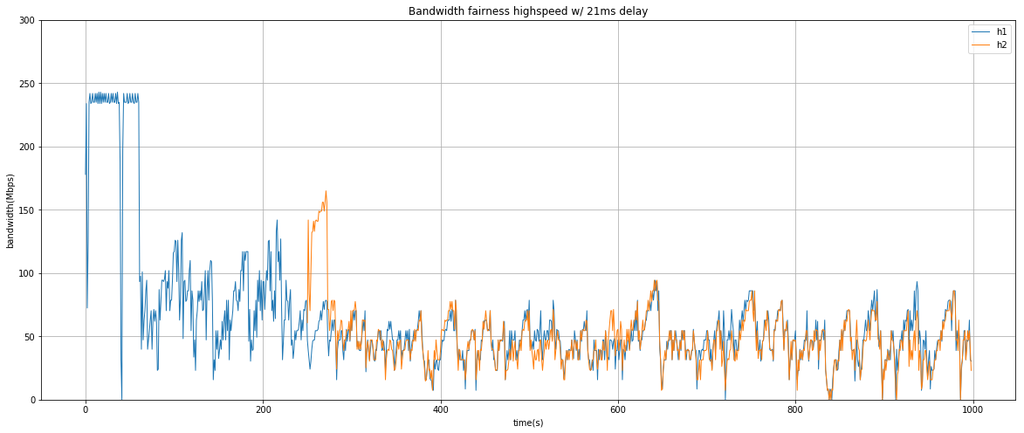

```python
run -i ./src/plot_fairness.py highspeed 21
```

#### Highspeed with 81ms delay

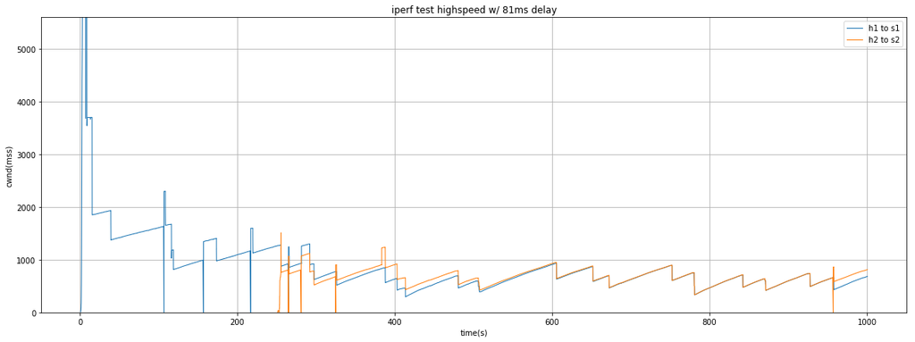

```python
run -i ./src/plot_tcpprobe.py highspeed 81
```

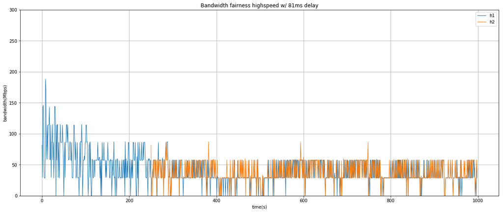

```python
run -i ./src/plot_fairness.py highspeed 81
```

#### Highspeed with 162ms delay

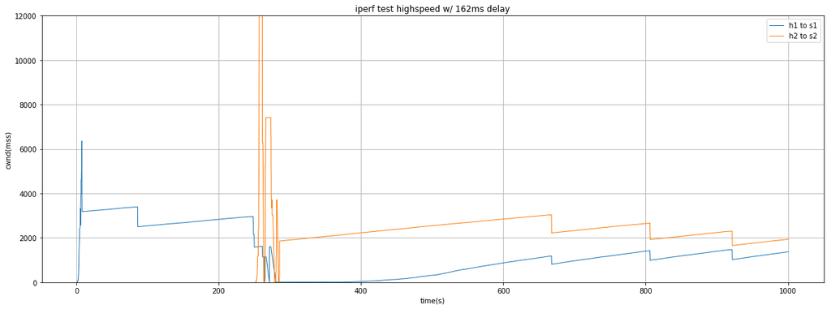

```python
run -i ./src/plot_tcpprobe.py highspeed 162
```

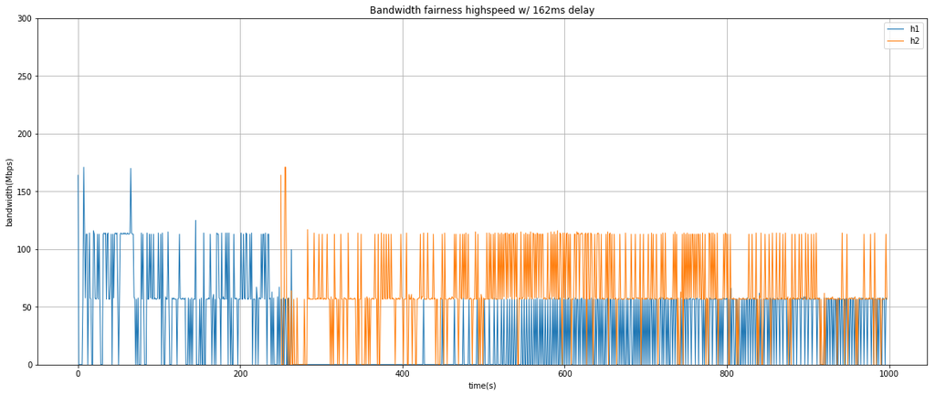

```python
run -i ./src/plot_fairness.py highspeed 162
```

### Observations

##### Cwnd changes

All the Highspeed graphs look similar to the Reno ones which have linear growth for cwnd, slow start and congestion avoidance phases can be identified. For the 162ms delay graph, the growth rate for cwnd is slightly greater than that in Reno, and on the other hand the cwnd drop size is smaller than Reno.

##### TCP Fairness

Both the hosts share very well in bandwidth, the bandwidth graphs show synchronized pattern for 21ms delay & 81ms delay right after h2 joins the transmission, both hosts converge slowly in the 162ms graph, they would share the same amount of bandwidth eventually.

##### Performance

Unlike other algorithm depending RTT, this is an algorithm specifically designed for handle the performance issue for large BDP connection, so it is more performant than the standard TCP congestion control model. Moreover, flows utilizing Highspeed is friendly to the standard TCP flows, because they behave very similarly, and able to get more available bandwidth quickly.

Average bandwidth utilization with 2 hosts is similar to Reno and it is approximately 150Mbps, which is 59% of the total bandwidth.

### Congestion Control Algorithm: Vegas

Vegas is a congestion algorithm using packet delay as a signal to determine the rate to send packets, while Reno and other algorithms are depending on packet loss. Vegas detects congestion at the initial stage based on the increasing RTT values of the sent packets, so Vegas is aware of congestion before packet loss happen.

#### Vegas with 21ms delay

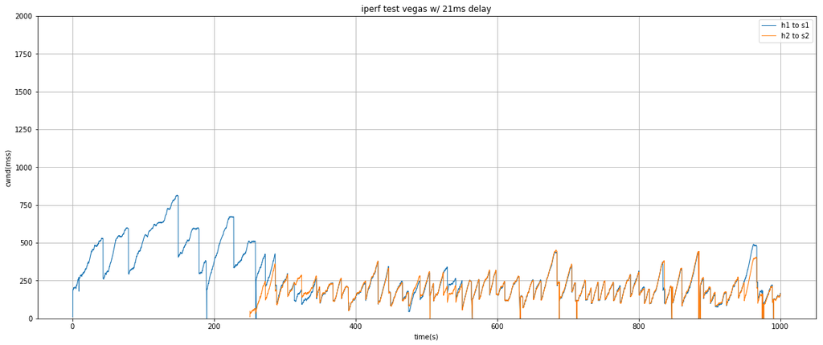

```python
run -i ./src/plot_tcpprobe.py vegas 21
```

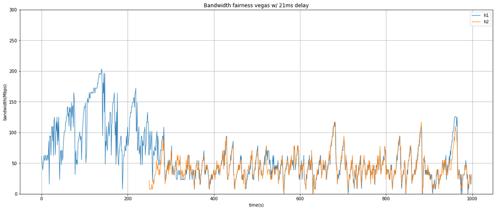

```python
run -i ./src/plot_fairness.py vegas 21
```

#### Vegas with 81ms delay

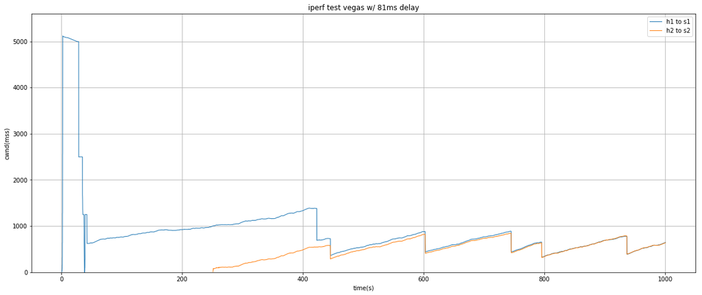

```python
run -i ./src/plot_tcpprobe.py vegas 81
```

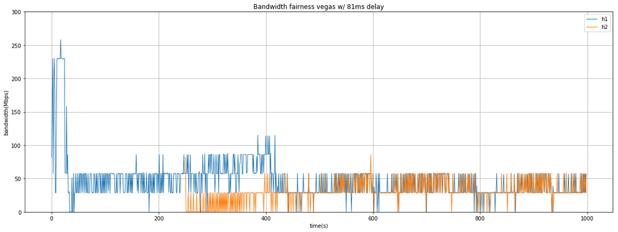

```python
run -i ./src/plot_fairness.py vegas 81
```

#### Vegas with 162ms delay

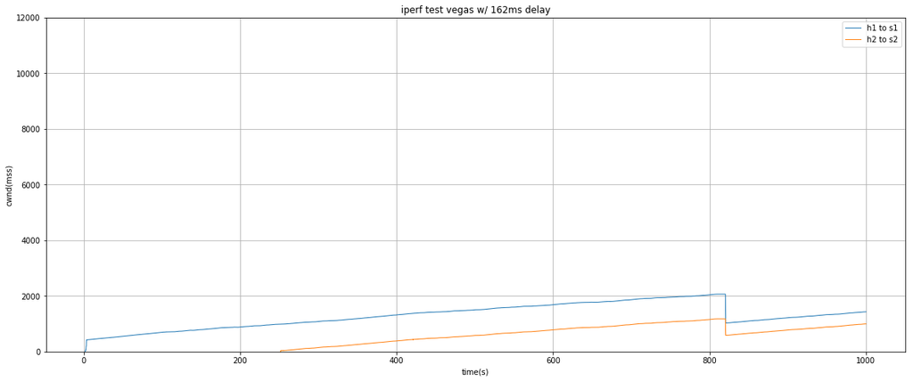

```python
run -i ./src/plot_tcpprobe.py vegas 162
```

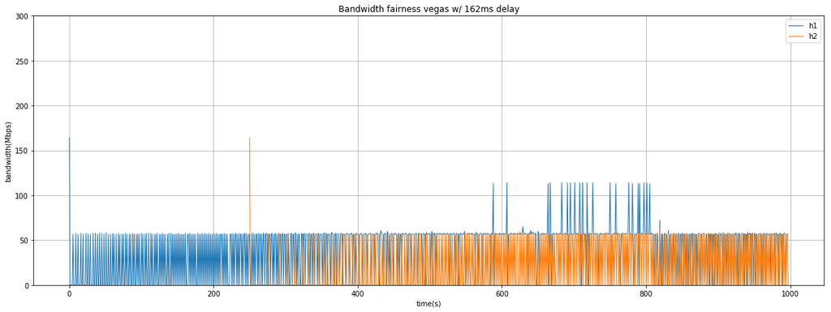

```python
run -i ./src/plot_fairness.py vegas 162
```

### Observations

##### Cwnd changes

The rate of cwnd change is non-linear and based on a function comparing current source rate and target rate, that reflects on the graph where the rates of changes for cwnd are not in straight lines. Also, the increasing rate is the slowest among the 4 algorithm with long RTT, and provides the most stable network.

##### Performance

Similar to Reno, the cwnd growth depends on RTT, in the 162ms delay graph, the cwnd slowly increases to 2000 after 800s, that's why it's not very competitive to other flows with shorter RTT. Beside, it detects congestions using packet delay, the sending rate decreases earlier and gives greater bandwidth to flows using other algorithm.

Average bandwidth utilization for Vegas with 2 hosts is approximately 120Mbps, which is 47% of the total bandwidth and it's the lowest among the 4 algorithms.

### Result comparison with the NIST book

This study sets up the same topology specified in Chapter 5 of the NIST book as close as possible using Mininet, except using one-way propagation delay instead of RTT for calculation the router buffer size, BDP for TCP window size on iperf.

The book tested only one algorithm picked in this study, Highspeed TCP, they provided the 3 graph with 42ms, 162ms & 324ms RTT, those graphs look different than the graphs in the study interns of data magnitude (link utilization & average cwnd) and noise level, those could caused by the configuration variables and testing environment, but the important thing is the graphs from the book and in this study are showing the same pattern and behavior of the algorithm.

### Improvements

The network simulation in this study works at a high level, more fine tuning and investigation is required to create a perfect topology for testing all congestion control models:

- to figure out all the variables and configure the topology precisely before collecting data.
- to have a dedicated testing machine for running and collection data from the simulation, and isolating all the external interferences during the test.

### References

- all the data and source files of this study can be found in [this Github repo](https://github.com/jeffhem/TCP-Congestion-Control)
- the [online book](https://www.nist.gov/document-15389) from NIST